# Risk Factor Analysis

## Outcome Variable

**Outcome Variable:** sstunted

## Predictor Variables

**Intervention Variable:** mhtcm

**Adjustment Set:**

unadjusted

## Stratifying Variables

The analysis was stratified on these variable(s):

- agecat
- studyid
- country

## Data Summary

| agecat | studyid | country | mhtcm | sstunted | n_cell | n |
| --- | --- | --- | --- | --- | --- | --- |
| Birth | ki0047075b-MAL-ED | BANGLADESH | >=155 cm | 0 | 24 | 246 |
| Birth | ki0047075b-MAL-ED | BANGLADESH | >=155 cm | 1 | 1 | 246 |
| Birth | ki0047075b-MAL-ED | BANGLADESH | <151 cm | 0 | 150 | 246 |
| Birth | ki0047075b-MAL-ED | BANGLADESH | <151 cm | 1 | 6 | 246 |
| Birth | ki0047075b-MAL-ED | BANGLADESH | [151-155) cm | 0 | 65 | 246 |
| Birth | ki0047075b-MAL-ED | BANGLADESH | [151-155) cm | 1 | 0 | 246 |
| Birth | ki0047075b-MAL-ED | BRAZIL | >=155 cm | 0 | 104 | 184 |
| Birth | ki0047075b-MAL-ED | BRAZIL | >=155 cm | 1 | 3 | 184 |
| Birth | ki0047075b-MAL-ED | BRAZIL | <151 cm | 0 | 46 | 184 |
| Birth | ki0047075b-MAL-ED | BRAZIL | <151 cm | 1 | 3 | 184 |
| Birth | ki0047075b-MAL-ED | BRAZIL | [151-155) cm | 0 | 26 | 184 |
| Birth | ki0047075b-MAL-ED | BRAZIL | [151-155) cm | 1 | 2 | 184 |
| Birth | ki0047075b-MAL-ED | INDIA | >=155 cm | 0 | 45 | 198 |
| Birth | ki0047075b-MAL-ED | INDIA | >=155 cm | 1 | 1 | 198 |
| Birth | ki0047075b-MAL-ED | INDIA | <151 cm | 0 | 91 | 198 |
| Birth | ki0047075b-MAL-ED | INDIA | <151 cm | 1 | 4 | 198 |
| Birth | ki0047075b-MAL-ED | INDIA | [151-155) cm | 0 | 55 | 198 |
| Birth | ki0047075b-MAL-ED | INDIA | [151-155) cm | 1 | 2 | 198 |
| Birth | ki0047075b-MAL-ED | NEPAL | >=155 cm | 0 | 27 | 172 |
| Birth | ki0047075b-MAL-ED | NEPAL | >=155 cm | 1 | 0 | 172 |
| Birth | ki0047075b-MAL-ED | NEPAL | <151 cm | 0 | 93 | 172 |
| Birth | ki0047075b-MAL-ED | NEPAL | <151 cm | 1 | 3 | 172 |
| Birth | ki0047075b-MAL-ED | NEPAL | [151-155) cm | 0 | 46 | 172 |
| Birth | ki0047075b-MAL-ED | NEPAL | [151-155) cm | 1 | 3 | 172 |
| Birth | ki0047075b-MAL-ED | PERU | >=155 cm | 0 | 57 | 276 |
| Birth | ki0047075b-MAL-ED | PERU | >=155 cm | 1 | 1 | 276 |
| Birth | ki0047075b-MAL-ED | PERU | <151 cm | 0 | 155 | 276 |
| Birth | ki0047075b-MAL-ED | PERU | <151 cm | 1 | 6 | 276 |
| Birth | ki0047075b-MAL-ED | PERU | [151-155) cm | 0 | 57 | 276 |
| Birth | ki0047075b-MAL-ED | PERU | [151-155) cm | 1 | 0 | 276 |

[output cut: 318 more lines]

The following strata were considered:

- agecat: 24 months, studyid: ki0047075b-MAL-ED, country: BANGLADESH
- agecat: 24 months, studyid: ki0047075b-MAL-ED, country: BRAZIL
- agecat: 24 months, studyid: ki0047075b-MAL-ED, country: INDIA
- agecat: 24 months, studyid: ki0047075b-MAL-ED, country: NEPAL
- agecat: 24 months, studyid: ki0047075b-MAL-ED, country: PERU
- agecat: 24 months, studyid: ki0047075b-MAL-ED, country: SOUTH AFRICA
- agecat: 24 months, studyid: ki0047075b-MAL-ED, country: TANZANIA, UNITED REPUBLIC OF
- agecat: 24 months, studyid: ki1017093-NIH-Birth, country: BANGLADESH
- agecat: 24 months, studyid: ki1017093b-PROVIDE, country: BANGLADESH
- agecat: 24 months, studyid: ki1017093c-NIH-Crypto, country: BANGLADESH
- agecat: 24 months, studyid: ki1066203-TanzaniaChild2, country: TANZANIA, UNITED REPUBLIC OF
- agecat: 24 months, studyid: ki1101329-Keneba, country: GAMBIA
- agecat: 24 months, studyid: ki1119695-PROBIT, country: BELARUS
- agecat: 24 months, studyid: ki1126311-ZVITAMBO, country: ZIMBABWE
- agecat: 24 months, studyid: ki1135781-COHORTS, country: GUATEMALA
- agecat: 24 months, studyid: ki1135781-COHORTS, country: INDIA
- agecat: 24 months, studyid: ki1135781-COHORTS, country: PHILIPPINES
- agecat: 24 months, studyid: ki1148112-LCNI-5, country: MALAWI
- agecat: 24 months, studyid: kiGH5241-JiVitA-3, country: BANGLADESH
- agecat: 6 months, studyid: ki0047075b-MAL-ED, country: BANGLADESH
- agecat: 6 months, studyid: ki0047075b-MAL-ED, country: BRAZIL
- agecat: 6 months, studyid: ki0047075b-MAL-ED, country: INDIA
- agecat: 6 months, studyid: ki0047075b-MAL-ED, country: NEPAL
- agecat: 6 months, studyid: ki0047075b-MAL-ED, country: PERU
- agecat: 6 months, studyid: ki0047075b-MAL-ED, country: SOUTH AFRICA
- agecat: 6 months, studyid: ki0047075b-MAL-ED, country: TANZANIA, UNITED REPUBLIC OF
- agecat: 6 months, studyid: ki1000304b-SAS-CompFeed, country: INDIA
- agecat: 6 months, studyid: ki1000304b-SAS-FoodSuppl, country: INDIA
- agecat: 6 months, studyid: ki1017093-NIH-Birth, country: BANGLADESH
- agecat: 6 months, studyid: ki1017093b-PROVIDE, country: BANGLADESH
- agecat: 6 months, studyid: ki1017093c-NIH-Crypto, country: BANGLADESH
- agecat: 6 months, studyid: ki1066203-TanzaniaChild2, country: TANZANIA, UNITED REPUBLIC OF
- agecat: 6 months, studyid: ki1101329-Keneba, country: GAMBIA
- agecat: 6 months, studyid: ki1112895-Guatemala BSC, country: GUATEMALA
- agecat: 6 months, studyid: ki1119695-PROBIT, country: BELARUS
- agecat: 6 months, studyid: ki1126311-ZVITAMBO, country: ZIMBABWE
- agecat: 6 months, studyid: ki1135781-COHORTS, country: GUATEMALA
- agecat: 6 months, studyid: ki1135781-COHORTS, country: INDIA
- agecat: 6 months, studyid: ki1135781-COHORTS, country: PHILIPPINES
- agecat: 6 months, studyid: ki1148112-LCNI-5, country: MALAWI
- agecat: 6 months, studyid: kiGH5241-JiVitA-3, country: BANGLADESH
- agecat: Birth, studyid: ki0047075b-MAL-ED, country: BANGLADESH
- agecat: Birth, studyid: ki0047075b-MAL-ED, country: BRAZIL
- agecat: Birth, studyid: ki0047075b-MAL-ED, country: INDIA
- agecat: Birth, studyid: ki0047075b-MAL-ED, country: NEPAL
- agecat: Birth, studyid: ki0047075b-MAL-ED, country: PERU
- agecat: Birth, studyid: ki0047075b-MAL-ED, country: SOUTH AFRICA
- agecat: Birth, studyid: ki0047075b-MAL-ED, country: TANZANIA, UNITED REPUBLIC OF
- agecat: Birth, studyid: ki1000304b-SAS-CompFeed, country: INDIA
- agecat: Birth, studyid: ki1017093-NIH-Birth, country: BANGLADESH
- agecat: Birth, studyid: ki1017093c-NIH-Crypto, country: BANGLADESH
- agecat: Birth, studyid: ki1101329-Keneba, country: GAMBIA
- agecat: Birth, studyid: ki1119695-PROBIT, country: BELARUS
- agecat: Birth, studyid: ki1126311-ZVITAMBO, country: ZIMBABWE
- agecat: Birth, studyid: ki1135781-COHORTS, country: GUATEMALA
- agecat: Birth, studyid: ki1135781-COHORTS, country: INDIA
- agecat: Birth, studyid: ki1135781-COHORTS, country: PHILIPPINES
- agecat: Birth, studyid: kiGH5241-JiVitA-3, country: BANGLADESH

### Dropped Strata

Some strata were dropped due to rare outcomes:

- agecat: Birth, studyid: ki0047075b-MAL-ED, country: BANGLADESH
- agecat: Birth, studyid: ki0047075b-MAL-ED, country: BRAZIL
- agecat: Birth, studyid: ki0047075b-MAL-ED, country: INDIA
- agecat: Birth, studyid: ki0047075b-MAL-ED, country: NEPAL
- agecat: Birth, studyid: ki0047075b-MAL-ED, country: PERU
- agecat: Birth, studyid: ki0047075b-MAL-ED, country: SOUTH AFRICA
- agecat: Birth, studyid: ki0047075b-MAL-ED, country: TANZANIA, UNITED REPUBLIC OF
- agecat: Birth, studyid: ki1000304b-SAS-CompFeed, country: INDIA
- agecat: Birth, studyid: ki1017093-NIH-Birth, country: BANGLADESH
- agecat: Birth, studyid: ki1017093c-NIH-Crypto, country: BANGLADESH
- agecat: Birth, studyid: ki1101329-Keneba, country: GAMBIA
- agecat: Birth, studyid: ki1119695-PROBIT, country: BELARUS
- agecat: Birth, studyid: ki1135781-COHORTS, country: GUATEMALA
- agecat: Birth, studyid: ki1135781-COHORTS, country: PHILIPPINES
- agecat: 6 months, studyid: ki0047075b-MAL-ED, country: BANGLADESH
- agecat: 6 months, studyid: ki0047075b-MAL-ED, country: BRAZIL
- agecat: 6 months, studyid: ki0047075b-MAL-ED, country: INDIA
- agecat: 6 months, studyid: ki0047075b-MAL-ED, country: NEPAL
- agecat: 6 months, studyid: ki0047075b-MAL-ED, country: PERU
- agecat: 6 months, studyid: ki0047075b-MAL-ED, country: SOUTH AFRICA
- agecat: 6 months, studyid: ki0047075b-MAL-ED, country: TANZANIA, UNITED REPUBLIC OF
- agecat: 6 months, studyid: ki1000304b-SAS-FoodSuppl, country: INDIA
- agecat: 6 months, studyid: ki1017093-NIH-Birth, country: BANGLADESH
- agecat: 6 months, studyid: ki1017093b-PROVIDE, country: BANGLADESH
- agecat: 6 months, studyid: ki1017093c-NIH-Crypto, country: BANGLADESH
- agecat: 6 months, studyid: ki1112895-Guatemala BSC, country: GUATEMALA
- agecat: 24 months, studyid: ki0047075b-MAL-ED, country: BANGLADESH
- agecat: 24 months, studyid: ki0047075b-MAL-ED, country: BRAZIL
- agecat: 24 months, studyid: ki0047075b-MAL-ED, country: INDIA
- agecat: 24 months, studyid: ki0047075b-MAL-ED, country: NEPAL
- agecat: 24 months, studyid: ki0047075b-MAL-ED, country: PERU
- agecat: 24 months, studyid: ki0047075b-MAL-ED, country: SOUTH AFRICA
- agecat: 24 months, studyid: ki1017093b-PROVIDE, country: BANGLADESH
- agecat: 24 months, studyid: ki1017093c-NIH-Crypto, country: BANGLADESH
- agecat: 24 months, studyid: ki1066203-TanzaniaChild2, country: TANZANIA, UNITED REPUBLIC OF
- agecat: 24 months, studyid: ki1119695-PROBIT, country: BELARUS

## Methods Detail

We’re interested in the causal parameters $E[Y_a]$ for all values of $a \in \mathcal{A}$. These parameters represent the mean outcome if, possibly contrary to fact, we intervened to set all units to have $A=a$. Under the randomization and positivity assumptions, these are identified by the statistical parameters $\psi_a=E_W[E_{Y|A,W}(Y|A=a,W)]$. In addition, we’re interested in the mean of $Y$, $E[Y]$ under no intervention (the observed mean). We will estimate these parameters by using SuperLearner to fit the relevant likelihood factors – $E_{Y|A,W}(Y|A=a,W)$ and $p(A=a|W)$, and then updating our likelihood fit using a joint TMLE.

For unadjusted analyses ($W=\{\}$), initial likelihoods were estimated using Lrnr_glm to estimate the simple $E(Y|A)$ and Lrnr_mean to estimate $p(A)$. For adjusted analyses, a small library containing Lrnr_glmnet, Lrnr_xgboost, and Lrnr_mean was used.

Having estimated these parameters, we will then use the delta method to estimate relative risks and attributable risks relative to a prespecified baseline level of $A$.

# Results Detail

## Results Plots

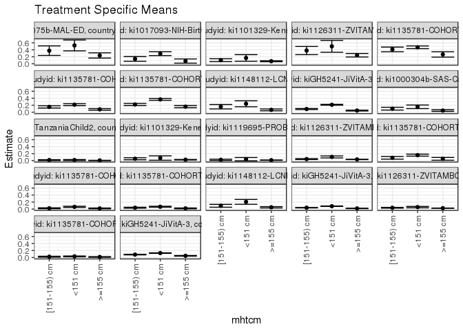

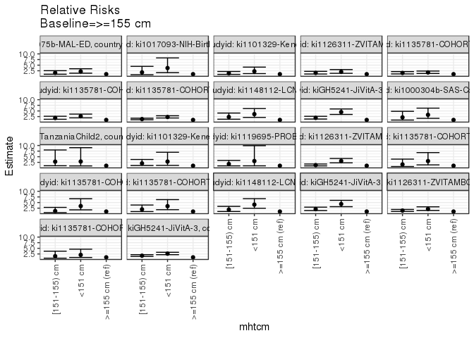

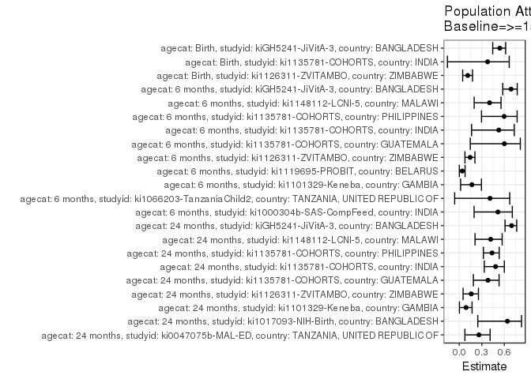

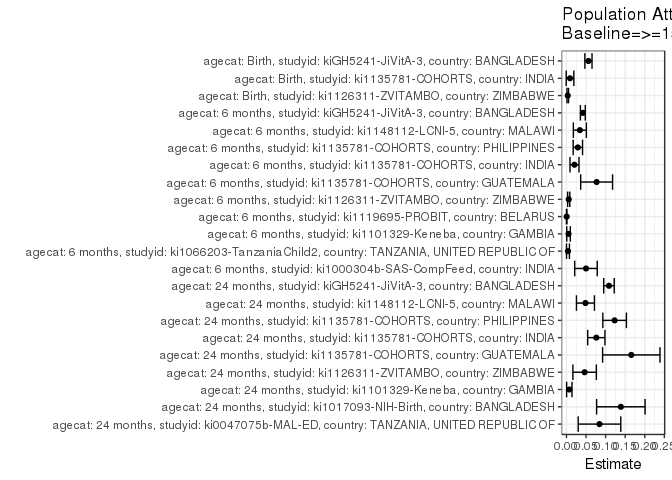

## Results Table

### Parameter: TSM

| agecat | studyid | country | intervention_level | baseline_level | estimate | ci_lower | ci_upper |
| --- | --- | --- | --- | --- | --- | --- | --- |
| Birth | ki1126311-ZVITAMBO | ZIMBABWE | >=155 cm | NA | 0.0259605 | 0.0224095 | 0.0295116 |
| Birth | ki1126311-ZVITAMBO | ZIMBABWE | <151 cm | NA | 0.0555556 | 0.0365489 | 0.0745622 |
| Birth | ki1126311-ZVITAMBO | ZIMBABWE | [151-155) cm | NA | 0.0370107 | 0.0271386 | 0.0468827 |
| Birth | ki1135781-COHORTS | INDIA | >=155 cm | NA | 0.0150943 | 0.0047110 | 0.0254777 |
| Birth | ki1135781-COHORTS | INDIA | <151 cm | NA | 0.0314548 | 0.0190665 | 0.0438431 |
| Birth | ki1135781-COHORTS | INDIA | [151-155) cm | NA | 0.0228690 | 0.0095062 | 0.0362318 |
| Birth | kiGH5241-JiVitA-3 | BANGLADESH | >=155 cm | NA | 0.0479310 | 0.0386759 | 0.0571861 |
| Birth | kiGH5241-JiVitA-3 | BANGLADESH | <151 cm | NA | 0.1266297 | 0.1201161 | 0.1331434 |
| Birth | kiGH5241-JiVitA-3 | BANGLADESH | [151-155) cm | NA | 0.0832483 | 0.0750303 | 0.0914664 |
| 6 months | ki1000304b-SAS-CompFeed | INDIA | >=155 cm | NA | 0.0470588 | 0.0233100 | 0.0708076 |
| 6 months | ki1000304b-SAS-CompFeed | INDIA | <151 cm | NA | 0.1543943 | 0.1034638 | 0.2053248 |
| 6 months | ki1000304b-SAS-CompFeed | INDIA | [151-155) cm | NA | 0.1010101 | 0.0609420 | 0.1410782 |
| 6 months | ki1066203-TanzaniaChild2 | TANZANIA, UNITED REPUBLIC OF | >=155 cm | NA | 0.0056180 | 0.0014669 | 0.0097691 |
| 6 months | ki1066203-TanzaniaChild2 | TANZANIA, UNITED REPUBLIC OF | <151 cm | NA | 0.0161812 | 0.0021097 | 0.0302527 |
| 6 months | ki1066203-TanzaniaChild2 | TANZANIA, UNITED REPUBLIC OF | [151-155) cm | NA | 0.0158730 | 0.0042051 | 0.0275409 |
| 6 months | ki1101329-Keneba | GAMBIA | >=155 cm | NA | 0.0261480 | 0.0182474 | 0.0340485 |
| 6 months | ki1101329-Keneba | GAMBIA | <151 cm | NA | 0.0746269 | 0.0116860 | 0.1375677 |
| 6 months | ki1101329-Keneba | GAMBIA | [151-155) cm | NA | 0.0537190 | 0.0253052 | 0.0821329 |
| 6 months | ki1119695-PROBIT | BELARUS | >=155 cm | NA | 0.0134046 | 0.0088341 | 0.0179751 |
| 6 months | ki1119695-PROBIT | BELARUS | <151 cm | NA | 0.0413223 | -0.0063617 | 0.0890063 |
| 6 months | ki1119695-PROBIT | BELARUS | [151-155) cm | NA | 0.0237467 | 0.0061571 | 0.0413363 |
| 6 months | ki1126311-ZVITAMBO | ZIMBABWE | >=155 cm | NA | 0.0342031 | 0.0294728 | 0.0389334 |
| 6 months | ki1126311-ZVITAMBO | ZIMBABWE | <151 cm | NA | 0.1064815 | 0.0773927 | 0.1355703 |
| 6 months | ki1126311-ZVITAMBO | ZIMBABWE | [151-155) cm | NA | 0.0440313 | 0.0314520 | 0.0566106 |
| 6 months | ki1135781-COHORTS | GUATEMALA | >=155 cm | NA | 0.0512821 | 0.0112934 | 0.0912707 |
| 6 months | ki1135781-COHORTS | GUATEMALA | <151 cm | NA | 0.1573927 | 0.1289181 | 0.1858673 |
| 6 months | ki1135781-COHORTS | GUATEMALA | [151-155) cm | NA | 0.0812183 | 0.0430521 | 0.1193844 |
| 6 months | ki1135781-COHORTS | INDIA | >=155 cm | NA | 0.0184843 | 0.0071311 | 0.0298375 |
| 6 months | ki1135781-COHORTS | INDIA | <151 cm | NA | 0.0632911 | 0.0463076 | 0.0802747 |
| 6 months | ki1135781-COHORTS | INDIA | [151-155) cm | NA | 0.0225410 | 0.0093677 | 0.0357142 |
| 6 months | ki1135781-COHORTS | PHILIPPINES | >=155 cm | NA | 0.0196078 | 0.0081326 | 0.0310831 |
| 6 months | ki1135781-COHORTS | PHILIPPINES | <151 cm | NA | 0.0665205 | 0.0533131 | 0.0797278 |
| 6 months | ki1135781-COHORTS | PHILIPPINES | [151-155) cm | NA | 0.0385109 | 0.0249957 | 0.0520261 |
| 6 months | ki1148112-LCNI-5 | MALAWI | >=155 cm | NA | 0.0506823 | 0.0316897 | 0.0696748 |
| 6 months | ki1148112-LCNI-5 | MALAWI | <151 cm | NA | 0.2061069 | 0.1367963 | 0.2754175 |
| 6 months | ki1148112-LCNI-5 | MALAWI | [151-155) cm | NA | 0.0937500 | 0.0524959 | 0.1350041 |
| 6 months | kiGH5241-JiVitA-3 | BANGLADESH | >=155 cm | NA | 0.0188218 | 0.0128958 | 0.0247477 |
| 6 months | kiGH5241-JiVitA-3 | BANGLADESH | <151 cm | NA | 0.0816639 | 0.0759357 | 0.0873922 |
| 6 months | kiGH5241-JiVitA-3 | BANGLADESH | [151-155) cm | NA | 0.0387389 | 0.0327881 | 0.0446898 |
| 24 months | ki0047075b-MAL-ED | TANZANIA, UNITED REPUBLIC OF | >=155 cm | NA | 0.2380952 | 0.1635525 | 0.3126380 |
| 24 months | ki0047075b-MAL-ED | TANZANIA, UNITED REPUBLIC OF | <151 cm | NA | 0.5250000 | 0.3698822 | 0.6801178 |
| 24 months | ki0047075b-MAL-ED | TANZANIA, UNITED REPUBLIC OF | [151-155) cm | NA | 0.3750000 | 0.2377222 | 0.5122778 |
| 24 months | ki1017093-NIH-Birth | BANGLADESH | >=155 cm | NA | 0.0779221 | 0.0179811 | 0.1378630 |
| 24 months | ki1017093-NIH-Birth | BANGLADESH | <151 cm | NA | 0.2896825 | 0.2336111 | 0.3457540 |
| 24 months | ki1017093-NIH-Birth | BANGLADESH | [151-155) cm | NA | 0.1400000 | 0.0719124 | 0.2080876 |
| 24 months | ki1101329-Keneba | GAMBIA | >=155 cm | NA | 0.0732436 | 0.0592792 | 0.0872081 |
| 24 months | ki1101329-Keneba | GAMBIA | <151 cm | NA | 0.1666667 | 0.0723384 | 0.2609949 |
| 24 months | ki1101329-Keneba | GAMBIA | [151-155) cm | NA | 0.1029412 | 0.0612280 | 0.1446544 |
| 24 months | ki1126311-ZVITAMBO | ZIMBABWE | >=155 cm | NA | 0.2446043 | 0.1940078 | 0.2952008 |
| 24 months | ki1126311-ZVITAMBO | ZIMBABWE | <151 cm | NA | 0.5000000 | 0.3317117 | 0.6682883 |
| 24 months | ki1126311-ZVITAMBO | ZIMBABWE | [151-155) cm | NA | 0.3787879 | 0.2616036 | 0.4959722 |
| 24 months | ki1135781-COHORTS | GUATEMALA | >=155 cm | NA | 0.2677165 | 0.1906721 | 0.3447610 |
| 24 months | ki1135781-COHORTS | GUATEMALA | <151 cm | NA | 0.4720121 | 0.4339359 | 0.5100883 |
| 24 months | ki1135781-COHORTS | GUATEMALA | [151-155) cm | NA | 0.4114833 | 0.3447337 | 0.4782328 |
| 24 months | ki1135781-COHORTS | INDIA | >=155 cm | NA | 0.0815217 | 0.0586884 | 0.1043551 |
| 24 months | ki1135781-COHORTS | INDIA | <151 cm | NA | 0.2152866 | 0.1865261 | 0.2440471 |
| 24 months | ki1135781-COHORTS | INDIA | [151-155) cm | NA | 0.1514523 | 0.1194397 | 0.1834648 |
| 24 months | ki1135781-COHORTS | PHILIPPINES | >=155 cm | NA | 0.1588235 | 0.1270948 | 0.1905523 |
| 24 months | ki1135781-COHORTS | PHILIPPINES | <151 cm | NA | 0.3670989 | 0.3401997 | 0.3939980 |
| 24 months | ki1135781-COHORTS | PHILIPPINES | [151-155) cm | NA | 0.2211127 | 0.1903856 | 0.2518398 |
| 24 months | ki1148112-LCNI-5 | MALAWI | >=155 cm | NA | 0.0676056 | 0.0414659 | 0.0937454 |
| 24 months | ki1148112-LCNI-5 | MALAWI | <151 cm | NA | 0.2421053 | 0.1558929 | 0.3283176 |
| 24 months | ki1148112-LCNI-5 | MALAWI | [151-155) cm | NA | 0.1574803 | 0.0940749 | 0.2208857 |
| 24 months | kiGH5241-JiVitA-3 | BANGLADESH | >=155 cm | NA | 0.0472741 | 0.0350028 | 0.0595454 |
| 24 months | kiGH5241-JiVitA-3 | BANGLADESH | <151 cm | NA | 0.2125556 | 0.2000945 | 0.2250167 |
| 24 months | kiGH5241-JiVitA-3 | BANGLADESH | [151-155) cm | NA | 0.0904568 | 0.0755729 | 0.1053407 |

### Parameter: E(Y)

| agecat | studyid | country | intervention_level | baseline_level | estimate | ci_lower | ci_upper |
| --- | --- | --- | --- | --- | --- | --- | --- |
| Birth | ki1126311-ZVITAMBO | ZIMBABWE | NA | NA | 0.0292749 | 0.0259142 | 0.0326355 |
| Birth | ki1135781-COHORTS | INDIA | NA | NA | 0.0242390 | 0.0170805 | 0.0313975 |
| Birth | kiGH5241-JiVitA-3 | BANGLADESH | NA | NA | 0.1040643 | 0.0993882 | 0.1087404 |
| 6 months | ki1000304b-SAS-CompFeed | INDIA | NA | NA | 0.0969055 | 0.0737418 | 0.1200693 |
| 6 months | ki1066203-TanzaniaChild2 | TANZANIA, UNITED REPUBLIC OF | NA | NA | 0.0095190 | 0.0052582 | 0.0137799 |
| 6 months | ki1101329-Keneba | GAMBIA | NA | NA | 0.0314331 | 0.0235374 | 0.0393288 |
| 6 months | ki1119695-PROBIT | BELARUS | NA | NA | 0.0139646 | 0.0092016 | 0.0187275 |
| 6 months | ki1126311-ZVITAMBO | ZIMBABWE | NA | NA | 0.0399944 | 0.0354446 | 0.0445442 |
| 6 months | ki1135781-COHORTS | GUATEMALA | NA | NA | 0.1283139 | 0.1069569 | 0.1496709 |
| 6 months | ki1135781-COHORTS | INDIA | NA | NA | 0.0390324 | 0.0301298 | 0.0479351 |
| 6 months | ki1135781-COHORTS | PHILIPPINES | NA | NA | 0.0487445 | 0.0406327 | 0.0568562 |
| 6 months | ki1148112-LCNI-5 | MALAWI | NA | NA | 0.0849282 | 0.0660197 | 0.1038368 |
| 6 months | kiGH5241-JiVitA-3 | BANGLADESH | NA | NA | 0.0606685 | 0.0568073 | 0.0645297 |
| 24 months | ki0047075b-MAL-ED | TANZANIA, UNITED REPUBLIC OF | NA | NA | 0.3224299 | 0.2596598 | 0.3852000 |
| 24 months | ki1017093-NIH-Birth | BANGLADESH | NA | NA | 0.2167832 | 0.1777459 | 0.2558205 |
| 24 months | ki1101329-Keneba | GAMBIA | NA | NA | 0.0805243 | 0.0671957 | 0.0938530 |
| 24 months | ki1126311-ZVITAMBO | ZIMBABWE | NA | NA | 0.2910053 | 0.2451542 | 0.3368563 |
| 24 months | ki1135781-COHORTS | GUATEMALA | NA | NA | 0.4332999 | 0.4025255 | 0.4640743 |
| 24 months | ki1135781-COHORTS | INDIA | NA | NA | 0.1577790 | 0.1410223 | 0.1745357 |
| 24 months | ki1135781-COHORTS | PHILIPPINES | NA | NA | 0.2817996 | 0.2639639 | 0.2996353 |
| 24 months | ki1148112-LCNI-5 | MALAWI | NA | NA | 0.1161179 | 0.0899551 | 0.1422806 |
| 24 months | kiGH5241-JiVitA-3 | BANGLADESH | NA | NA | 0.1558275 | 0.1470700 | 0.1645850 |

### Parameter: RR

| agecat | studyid | country | intervention_level | baseline_level | estimate | ci_lower | ci_upper |
| --- | --- | --- | --- | --- | --- | --- | --- |
| Birth | ki1126311-ZVITAMBO | ZIMBABWE | >=155 cm | >=155 cm | 1.000000 | 1.0000000 | 1.000000 |
| Birth | ki1126311-ZVITAMBO | ZIMBABWE | <151 cm | >=155 cm | 2.140000 | 1.4804624 | 3.093358 |
| Birth | ki1126311-ZVITAMBO | ZIMBABWE | [151-155) cm | >=155 cm | 1.425651 | 1.0563984 | 1.923972 |
| Birth | ki1135781-COHORTS | INDIA | >=155 cm | >=155 cm | 1.000000 | 1.0000000 | 1.000000 |
| Birth | ki1135781-COHORTS | INDIA | <151 cm | >=155 cm | 2.083879 | 0.9432426 | 4.603856 |
| Birth | ki1135781-COHORTS | INDIA | [151-155) cm | >=155 cm | 1.515073 | 0.6144022 | 3.736063 |
| Birth | kiGH5241-JiVitA-3 | BANGLADESH | >=155 cm | >=155 cm | 1.000000 | 1.0000000 | 1.000000 |
| Birth | kiGH5241-JiVitA-3 | BANGLADESH | <151 cm | >=155 cm | 2.641915 | 2.1632157 | 3.226547 |
| Birth | kiGH5241-JiVitA-3 | BANGLADESH | [151-155) cm | >=155 cm | 1.736835 | 1.3934801 | 2.164794 |
| 6 months | ki1000304b-SAS-CompFeed | INDIA | >=155 cm | >=155 cm | 1.000000 | 1.0000000 | 1.000000 |
| 6 months | ki1000304b-SAS-CompFeed | INDIA | <151 cm | >=155 cm | 3.280879 | 1.7226455 | 6.248625 |
| 6 months | ki1000304b-SAS-CompFeed | INDIA | [151-155) cm | >=155 cm | 2.146465 | 0.9524608 | 4.837270 |
| 6 months | ki1066203-TanzaniaChild2 | TANZANIA, UNITED REPUBLIC OF | >=155 cm | >=155 cm | 1.000000 | 1.0000000 | 1.000000 |
| 6 months | ki1066203-TanzaniaChild2 | TANZANIA, UNITED REPUBLIC OF | <151 cm | >=155 cm | 2.880259 | 0.9201086 | 9.016209 |
| 6 months | ki1066203-TanzaniaChild2 | TANZANIA, UNITED REPUBLIC OF | [151-155) cm | >=155 cm | 2.825397 | 0.9963933 | 8.011763 |
| 6 months | ki1101329-Keneba | GAMBIA | >=155 cm | >=155 cm | 1.000000 | 1.0000000 | 1.000000 |
| 6 months | ki1101329-Keneba | GAMBIA | <151 cm | >=155 cm | 2.854023 | 1.1651317 | 6.991008 |
| 6 months | ki1101329-Keneba | GAMBIA | [151-155) cm | >=155 cm | 2.054425 | 1.1172215 | 3.777819 |
| 6 months | ki1119695-PROBIT | BELARUS | >=155 cm | >=155 cm | 1.000000 | 1.0000000 | 1.000000 |
| 6 months | ki1119695-PROBIT | BELARUS | <151 cm | >=155 cm | 3.082694 | 0.9585581 | 9.913850 |
| 6 months | ki1119695-PROBIT | BELARUS | [151-155) cm | >=155 cm | 1.771532 | 0.9357442 | 3.353829 |
| 6 months | ki1126311-ZVITAMBO | ZIMBABWE | >=155 cm | >=155 cm | 1.000000 | 1.0000000 | 1.000000 |
| 6 months | ki1126311-ZVITAMBO | ZIMBABWE | <151 cm | >=155 cm | 3.113211 | 2.2920817 | 4.228507 |
| 6 months | ki1126311-ZVITAMBO | ZIMBABWE | [151-155) cm | >=155 cm | 1.287348 | 0.9372369 | 1.768247 |
| 6 months | ki1135781-COHORTS | GUATEMALA | >=155 cm | >=155 cm | 1.000000 | 1.0000000 | 1.000000 |
| 6 months | ki1135781-COHORTS | GUATEMALA | <151 cm | >=155 cm | 3.069157 | 1.3783850 | 6.833887 |
| 6 months | ki1135781-COHORTS | GUATEMALA | [151-155) cm | >=155 cm | 1.583756 | 0.6372270 | 3.936249 |
| 6 months | ki1135781-COHORTS | INDIA | >=155 cm | >=155 cm | 1.000000 | 1.0000000 | 1.000000 |
| 6 months | ki1135781-COHORTS | INDIA | <151 cm | >=155 cm | 3.424051 | 1.7516471 | 6.693199 |
| 6 months | ki1135781-COHORTS | INDIA | [151-155) cm | >=155 cm | 1.219467 | 0.5223580 | 2.846898 |
| 6 months | ki1135781-COHORTS | PHILIPPINES | >=155 cm | >=155 cm | 1.000000 | 1.0000000 | 1.000000 |
| 6 months | ki1135781-COHORTS | PHILIPPINES | <151 cm | >=155 cm | 3.392544 | 1.8286555 | 6.293888 |
| 6 months | ki1135781-COHORTS | PHILIPPINES | [151-155) cm | >=155 cm | 1.964057 | 0.9926424 | 3.886110 |
| 6 months | ki1148112-LCNI-5 | MALAWI | >=155 cm | >=155 cm | 1.000000 | 1.0000000 | 1.000000 |
| 6 months | ki1148112-LCNI-5 | MALAWI | <151 cm | >=155 cm | 4.066647 | 2.4579202 | 6.728298 |
| 6 months | ki1148112-LCNI-5 | MALAWI | [151-155) cm | >=155 cm | 1.849760 | 1.0377665 | 3.297091 |
| 6 months | kiGH5241-JiVitA-3 | BANGLADESH | >=155 cm | >=155 cm | 1.000000 | 1.0000000 | 1.000000 |
| 6 months | kiGH5241-JiVitA-3 | BANGLADESH | <151 cm | >=155 cm | 4.338805 | 3.1495666 | 5.977086 |
| 6 months | kiGH5241-JiVitA-3 | BANGLADESH | [151-155) cm | >=155 cm | 2.058200 | 1.4377593 | 2.946382 |
| 24 months | ki0047075b-MAL-ED | TANZANIA, UNITED REPUBLIC OF | >=155 cm | >=155 cm | 1.000000 | 1.0000000 | 1.000000 |
| 24 months | ki0047075b-MAL-ED | TANZANIA, UNITED REPUBLIC OF | <151 cm | >=155 cm | 2.205000 | 1.4336777 | 3.391296 |
| 24 months | ki0047075b-MAL-ED | TANZANIA, UNITED REPUBLIC OF | [151-155) cm | >=155 cm | 1.575000 | 0.9729343 | 2.549633 |
| 24 months | ki1017093-NIH-Birth | BANGLADESH | >=155 cm | >=155 cm | 1.000000 | 1.0000000 | 1.000000 |
| 24 months | ki1017093-NIH-Birth | BANGLADESH | <151 cm | >=155 cm | 3.717593 | 1.6817843 | 8.217757 |
| 24 months | ki1017093-NIH-Birth | BANGLADESH | [151-155) cm | >=155 cm | 1.796667 | 0.7231383 | 4.463892 |
| 24 months | ki1101329-Keneba | GAMBIA | >=155 cm | >=155 cm | 1.000000 | 1.0000000 | 1.000000 |
| 24 months | ki1101329-Keneba | GAMBIA | <151 cm | >=155 cm | 2.275510 | 1.2523031 | 4.134739 |
| 24 months | ki1101329-Keneba | GAMBIA | [151-155) cm | >=155 cm | 1.405462 | 0.8981121 | 2.199418 |
| 24 months | ki1126311-ZVITAMBO | ZIMBABWE | >=155 cm | >=155 cm | 1.000000 | 1.0000000 | 1.000000 |
| 24 months | ki1126311-ZVITAMBO | ZIMBABWE | <151 cm | >=155 cm | 2.044118 | 1.3770014 | 3.034432 |
| 24 months | ki1126311-ZVITAMBO | ZIMBABWE | [151-155) cm | >=155 cm | 1.548574 | 1.0673573 | 2.246747 |
| 24 months | ki1135781-COHORTS | GUATEMALA | >=155 cm | >=155 cm | 1.000000 | 1.0000000 | 1.000000 |
| 24 months | ki1135781-COHORTS | GUATEMALA | <151 cm | >=155 cm | 1.763104 | 1.3076088 | 2.377267 |
| 24 months | ki1135781-COHORTS | GUATEMALA | [151-155) cm | >=155 cm | 1.537011 | 1.1046025 | 2.138690 |
| 24 months | ki1135781-COHORTS | INDIA | >=155 cm | >=155 cm | 1.000000 | 1.0000000 | 1.000000 |
| 24 months | ki1135781-COHORTS | INDIA | <151 cm | >=155 cm | 2.640849 | 1.9363095 | 3.601741 |
| 24 months | ki1135781-COHORTS | INDIA | [151-155) cm | >=155 cm | 1.857815 | 1.3080089 | 2.638725 |
| 24 months | ki1135781-COHORTS | PHILIPPINES | >=155 cm | >=155 cm | 1.000000 | 1.0000000 | 1.000000 |
| 24 months | ki1135781-COHORTS | PHILIPPINES | <151 cm | >=155 cm | 2.311363 | 1.8683386 | 2.859439 |
| 24 months | ki1135781-COHORTS | PHILIPPINES | [151-155) cm | >=155 cm | 1.392191 | 1.0914697 | 1.775767 |
| 24 months | ki1148112-LCNI-5 | MALAWI | >=155 cm | >=155 cm | 1.000000 | 1.0000000 | 1.000000 |
| 24 months | ki1148112-LCNI-5 | MALAWI | <151 cm | >=155 cm | 3.581140 | 2.1170778 | 6.057673 |
| 24 months | ki1148112-LCNI-5 | MALAWI | [151-155) cm | >=155 cm | 2.329396 | 1.3329482 | 4.070741 |
| 24 months | kiGH5241-JiVitA-3 | BANGLADESH | >=155 cm | >=155 cm | 1.000000 | 1.0000000 | 1.000000 |
| 24 months | kiGH5241-JiVitA-3 | BANGLADESH | <151 cm | >=155 cm | 4.496237 | 3.4463370 | 5.865980 |
| 24 months | kiGH5241-JiVitA-3 | BANGLADESH | [151-155) cm | >=155 cm | 1.913453 | 1.4014039 | 2.612597 |

### Parameter: PAR

| agecat | studyid | country | intervention_level | baseline_level | estimate | ci_lower | ci_upper |
| --- | --- | --- | --- | --- | --- | --- | --- |
| Birth | ki1126311-ZVITAMBO | ZIMBABWE | >=155 cm | NA | 0.0033143 | 0.0013637 | 0.0052650 |
| Birth | ki1135781-COHORTS | INDIA | >=155 cm | NA | 0.0091447 | -0.0005835 | 0.0188728 |
| Birth | kiGH5241-JiVitA-3 | BANGLADESH | >=155 cm | NA | 0.0561333 | 0.0469766 | 0.0652899 |
| 6 months | ki1000304b-SAS-CompFeed | INDIA | >=155 cm | NA | 0.0498467 | 0.0210540 | 0.0786394 |
| 6 months | ki1066203-TanzaniaChild2 | TANZANIA, UNITED REPUBLIC OF | >=155 cm | NA | 0.0039011 | 0.0001764 | 0.0076257 |
| 6 months | ki1101329-Keneba | GAMBIA | >=155 cm | NA | 0.0052852 | 0.0007603 | 0.0098101 |
| 6 months | ki1119695-PROBIT | BELARUS | >=155 cm | NA | 0.0005599 | -0.0000136 | 0.0011335 |
| 6 months | ki1126311-ZVITAMBO | ZIMBABWE | >=155 cm | NA | 0.0057913 | 0.0030607 | 0.0085219 |
| 6 months | ki1135781-COHORTS | GUATEMALA | >=155 cm | NA | 0.0770318 | 0.0363083 | 0.1177554 |
| 6 months | ki1135781-COHORTS | INDIA | >=155 cm | NA | 0.0205481 | 0.0090816 | 0.0320147 |
| 6 months | ki1135781-COHORTS | PHILIPPINES | >=155 cm | NA | 0.0291366 | 0.0171816 | 0.0410916 |
| 6 months | ki1148112-LCNI-5 | MALAWI | >=155 cm | NA | 0.0342460 | 0.0176462 | 0.0508457 |
| 6 months | kiGH5241-JiVitA-3 | BANGLADESH | >=155 cm | NA | 0.0418468 | 0.0356206 | 0.0480729 |
| 24 months | ki0047075b-MAL-ED | TANZANIA, UNITED REPUBLIC OF | >=155 cm | NA | 0.0843347 | 0.0299895 | 0.1386799 |
| 24 months | ki1017093-NIH-Birth | BANGLADESH | >=155 cm | NA | 0.1388611 | 0.0769979 | 0.2007244 |
| 24 months | ki1101329-Keneba | GAMBIA | >=155 cm | NA | 0.0072807 | 0.0004310 | 0.0141304 |
| 24 months | ki1126311-ZVITAMBO | ZIMBABWE | >=155 cm | NA | 0.0464010 | 0.0164541 | 0.0763479 |
| 24 months | ki1135781-COHORTS | GUATEMALA | >=155 cm | NA | 0.1655834 | 0.0922985 | 0.2388682 |
| 24 months | ki1135781-COHORTS | INDIA | >=155 cm | NA | 0.0762573 | 0.0542182 | 0.0982963 |
| 24 months | ki1135781-COHORTS | PHILIPPINES | >=155 cm | NA | 0.1229761 | 0.0928954 | 0.1530567 |
| 24 months | ki1148112-LCNI-5 | MALAWI | >=155 cm | NA | 0.0485122 | 0.0255559 | 0.0714685 |
| 24 months | kiGH5241-JiVitA-3 | BANGLADESH | >=155 cm | NA | 0.1085534 | 0.0951102 | 0.1219966 |

### Parameter: PAF

| agecat | studyid | country | intervention_level | baseline_level | estimate | ci_lower | ci_upper |
| --- | --- | --- | --- | --- | --- | --- | --- |
| Birth | ki1126311-ZVITAMBO | ZIMBABWE | >=155 cm | NA | 0.1132136 | 0.0453184 | 0.1762803 |
| Birth | ki1135781-COHORTS | INDIA | >=155 cm | NA | 0.3772707 | -0.1575587 | 0.6649917 |
| Birth | kiGH5241-JiVitA-3 | BANGLADESH | >=155 cm | NA | 0.5394094 | 0.4453135 | 0.6175430 |
| 6 months | ki1000304b-SAS-CompFeed | INDIA | >=155 cm | NA | 0.5143846 | 0.1975358 | 0.7061273 |
| 6 months | ki1066203-TanzaniaChild2 | TANZANIA, UNITED REPUBLIC OF | >=155 cm | NA | 0.4098167 | -0.0610110 | 0.6717128 |
| 6 months | ki1101329-Keneba | GAMBIA | >=155 cm | NA | 0.1681403 | 0.0180716 | 0.2952740 |
| 6 months | ki1119695-PROBIT | BELARUS | >=155 cm | NA | 0.0400972 | 0.0014302 | 0.0772670 |
| 6 months | ki1126311-ZVITAMBO | ZIMBABWE | >=155 cm | NA | 0.1448024 | 0.0757528 | 0.2086934 |
| 6 months | ki1135781-COHORTS | GUATEMALA | >=155 cm | NA | 0.6003391 | 0.1466206 | 0.8128278 |
| 6 months | ki1135781-COHORTS | INDIA | >=155 cm | NA | 0.5264377 | 0.1640075 | 0.7317425 |
| 6 months | ki1135781-COHORTS | PHILIPPINES | >=155 cm | NA | 0.5977421 | 0.2960849 | 0.7701266 |
| 6 months | ki1148112-LCNI-5 | MALAWI | >=155 cm | NA | 0.4032342 | 0.1983002 | 0.5557821 |
| 6 months | kiGH5241-JiVitA-3 | BANGLADESH | >=155 cm | NA | 0.6897607 | 0.5789195 | 0.7714252 |
| 24 months | ki0047075b-MAL-ED | TANZANIA, UNITED REPUBLIC OF | >=155 cm | NA | 0.2615597 | 0.0751117 | 0.4104217 |
| 24 months | ki1017093-NIH-Birth | BANGLADESH | >=155 cm | NA | 0.6405530 | 0.2465165 | 0.8285269 |
| 24 months | ki1101329-Keneba | GAMBIA | >=155 cm | NA | 0.0904161 | 0.0024699 | 0.1706086 |
| 24 months | ki1126311-ZVITAMBO | ZIMBABWE | >=155 cm | NA | 0.1594506 | 0.0510565 | 0.2554633 |
| 24 months | ki1135781-COHORTS | GUATEMALA | >=155 cm | NA | 0.3821449 | 0.1877568 | 0.5300116 |
| 24 months | ki1135781-COHORTS | INDIA | >=155 cm | NA | 0.4833169 | 0.3331057 | 0.5996946 |
| 24 months | ki1135781-COHORTS | PHILIPPINES | >=155 cm | NA | 0.4363955 | 0.3212995 | 0.5319731 |
| 24 months | ki1148112-LCNI-5 | MALAWI | >=155 cm | NA | 0.4177843 | 0.2099759 | 0.5709307 |
| 24 months | kiGH5241-JiVitA-3 | BANGLADESH | >=155 cm | NA | 0.6966254 | 0.6091271 | 0.7645368 |